# Time Series 6

2024-05-02

## R Markdown

Part A

Load data from TSA package (the package is written by authors Jonathan Cryer and Kung-Sik Chan).

> library(“TSA”)

> data(beersales)

The data is the monthly beer sales in millions of barrels, 01/1975 - 12/1990.

Train: 01/1975 - 12/1989.

Test: 1990

```r
library(TSA)
data(beersales)
library(xts)
train <- window(beersales, start=c(1975,1), end=c(1989,12))
test <- window(beersales, start=c(1990,1), end=c(1990,12))
```

Part 1 - use ARIMA(p,d,q) model to forecast beer sales for all months of 1990 using the following two multi-step forecasting approaches. For each model, check mean, autocorrelation and normality of the residuals. Confirm if the residuals are white noise.

Mean Residuals: The computed mean of the residuals was -0.01226384, indicating a very slight negative bias but close enough to zero for practical purposes. ACF of Residuals: The ACF plot did not show significant correlations, suggesting that the residuals might be white noise, although further statistical testing would be needed for confirmation. Normality Test: The Shapiro-Wilk test returned a p-value of 5.15e-07, indicating that the residuals do not follow a normal distribution. This suggests potential issues with the model assumptions or that transformation might be needed. The non normality suggests that residuals are not fully white noise

```r
library(forecast)
```

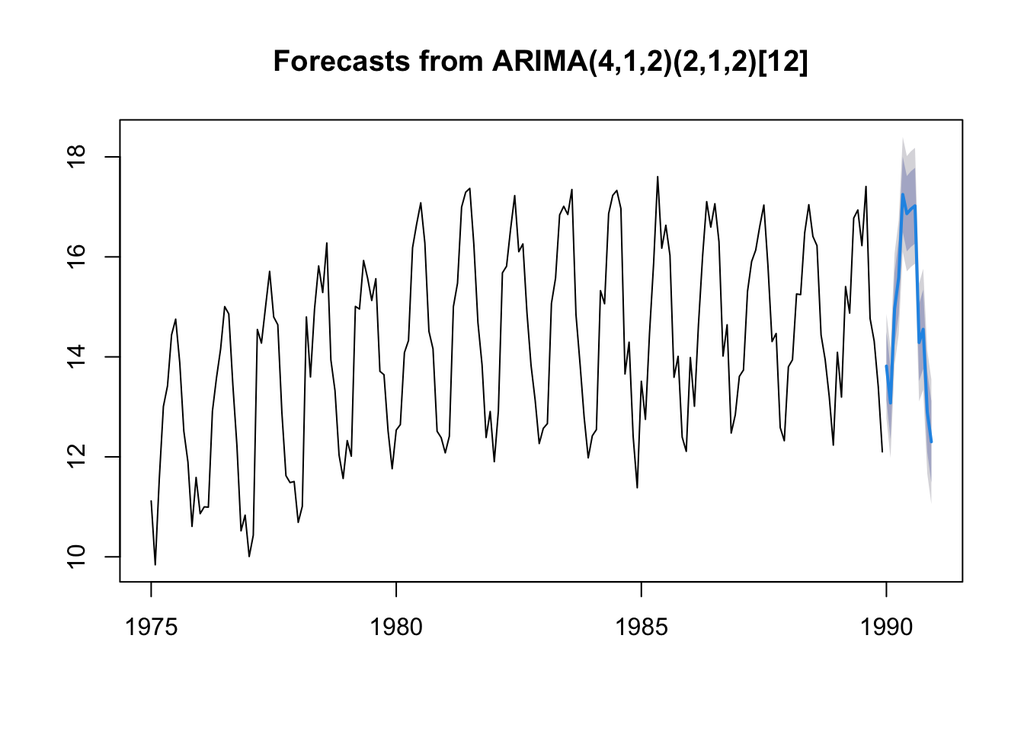

```r
fit_arima <- auto.arima(train)

forecasts_beer <- forecast(fit_arima, h=12)
plot(forecasts_beer)
```

1A - Use the h-period in forecast() to forecast each month of 1990. This is also known as recursive forecasting where you fit a model only once and use it recursively for h-periods.

```r
mean_residuals_arima <- mean(residuals(fit_arima))
print (mean_residuals_arima)
```

```
## [1] -0.01226384
```

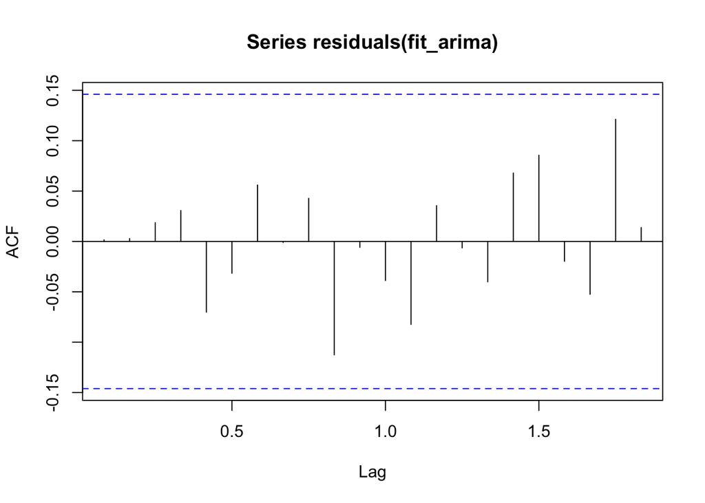

```r
acf(residuals(fit_arima))
```

```r
shapiro.test(residuals(fit_arima))
```

```
##
##  Shapiro-Wilk normality test
##
## data:  residuals(fit_arima)
## W = 0.93789, p-value = 5.15e-07
```

```r
library(forecast)
library(dplyr)
adjusted_training1 <- train
forecasts_1 <- numeric(12)
model_listbeer <- vector("list", 12)

for (month_index in 1:12) {
  current_model <- auto.arima(adjusted_training1)
  model_listbeer[[month_index]] <- current_model
  next_forecast <- forecast(current_model, h=1)$mean
  forecasts_1[month_index] <- next_forecast
  adjusted_training1 <-ts(c(adjusted_training1,next_forecast),start=c(1975,1),frequency= 12)
}
```

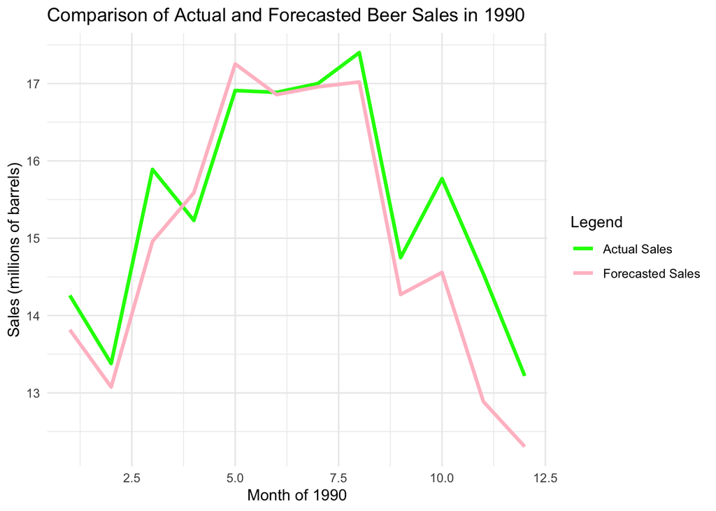

```r
df <- data.frame(
  month = 1:12,
  actual_sales = test,
  direct_recursive_forecast = forecasts_1
) %>%
  mutate(
    forecast_error = direct_recursive_forecast - actual_sales
)
library(ggplot2)

pforcast <- ggplot(df, aes(x = month)) +
   geom_line(aes(y = actual_sales, colour = "Actual Sales"), size=1.2) +
   geom_line(aes(y = direct_recursive_forecast, colour = "Forecasted Sales"), size=1.2) +
   labs(title = "Comparison of Actual and Forecasted Beer Sales in 1990",
      x = "Month of 1990",
      y = "Sales (millions of barrels)", colour = "Legend") +
    theme_minimal() +
    scale_colour_manual(values = c("Actual Sales" = "green", "Forecasted Sales" = "pink"))
print(pforcast)
```

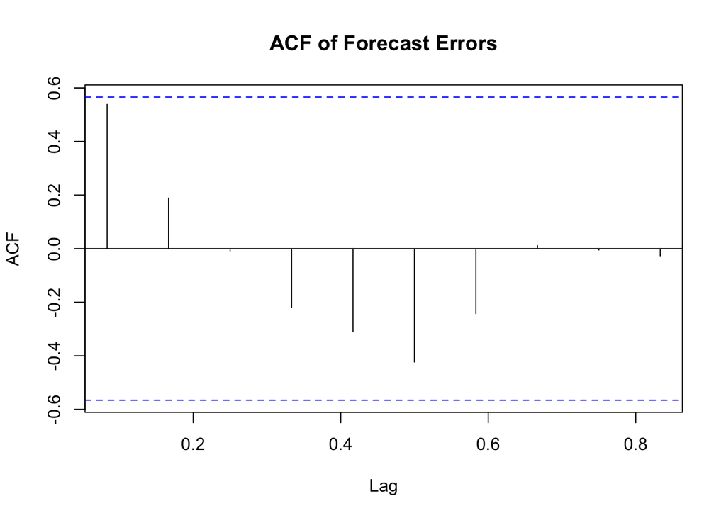

```r
library(stats)

mean_residuals_arima <- mean(df$forecast_error)
acf_plot <- acf(df$forecast_error, main="ACF of Forecast Errors")
```

```r
shapiro <- shapiro.test(df$forecast_error)

list(
  MeanResiduals = mean_residuals_arima,
  ACFPlot = acf_plot,
  ShapiroWilkTest = shapiro
)
```

```
## $MeanResiduals
## [1] -0.4738695
##
## $ACFPlot
##
## Autocorrelations of series 'df$forecast_error', by lag
##
## 0.0833 0.1667 0.2500 0.3333 0.4167 0.5000 0.5833 0.6667 0.7500 0.8333
##  0.538  0.189 -0.008 -0.219 -0.310 -0.423 -0.243  0.011 -0.005 -0.027
##
## $ShapiroWilkTest
##
##  Shapiro-Wilk normality test
##
## data:  df$forecast_error
## W = 0.95714, p-value = 0.7424
```

1C - Plot the mean, the p-value of the autocorrelation test and the p-value of the normality test of the residuals of the 12 models.

```r
library(tidyverse)
```

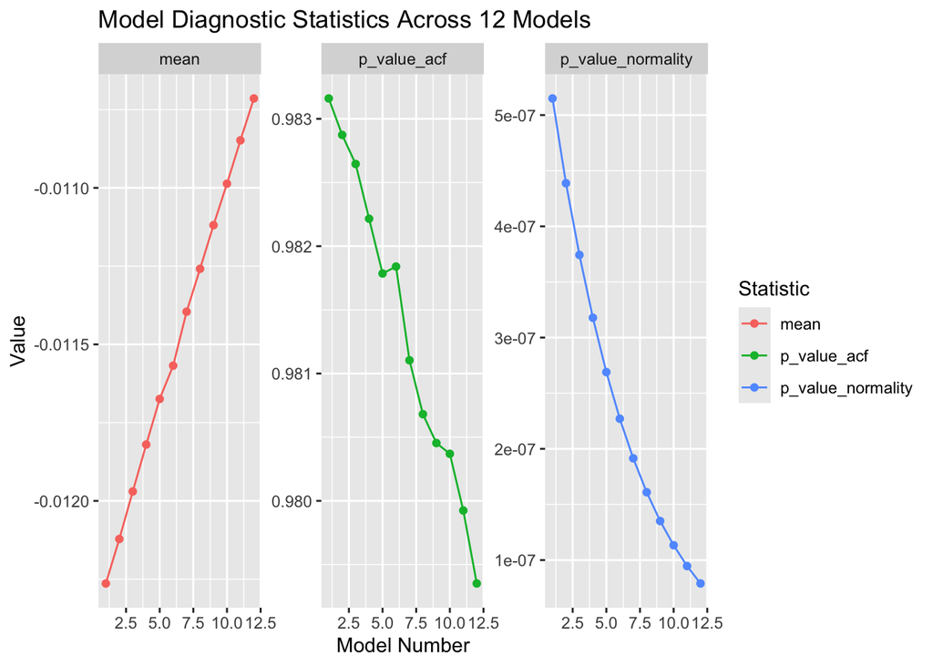

```r
library(broom)

# Calculate metrics for each model
results <- map_df(model_listbeer, function(model) {
  residuals <- residuals(model)
  acf_res <- Box.test(residuals, type="Ljung-Box")
  shapiro_res <- shapiro.test(residuals)
  tibble(
    mean = mean(residuals),
    p_value_acf = acf_res$p.value,
    p_value_normality = shapiro_res$p.value
  )
})

# Add model identifier
results$model <- 1:12

# Plotting
results %>%
  gather(key = "Statistic", value = "Value", -model) %>%
  ggplot(aes(x = model, y = Value, color = Statistic)) +
  geom_line() +
  geom_point() +
  facet_wrap(~ Statistic, scales = "free_y") +
  labs(title = "Model Diagnostic Statistics Across 12 Models",
       x = "Model Number",
       y = "Value")
```

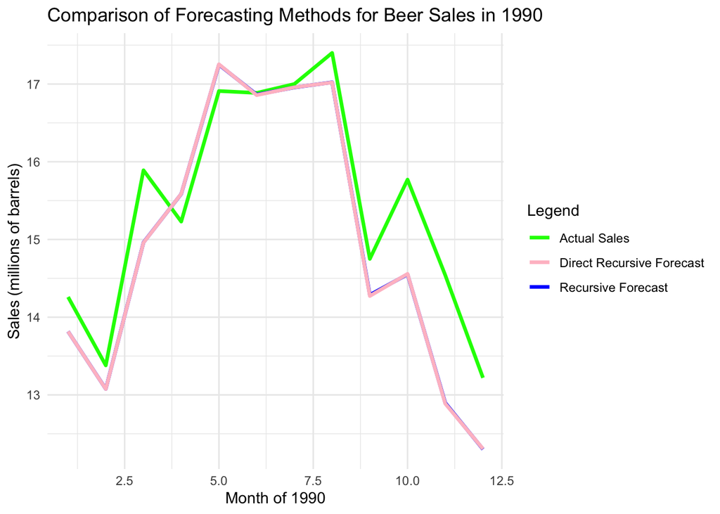

```r
#2 - Plot the Recursive and DirRec along with the actuals. Use ylim=c(12.5, 17) to get a good visual of the plot differences.
#Plot the Recursive and Direct Recursive along with the Actuals

direct_recursive_forecast <- forecasts_beer$mean

# Creating the comparison data frame
comparison_df <- data.frame(
  month = 1:12,
  actual_sales = test,
  recursive_forecast = direct_recursive_forecast,
  direct_recursive_forecast = forecasts_1
)

# Plotting both forecasts with actual data without restricted y-limits
ggplot(comparison_df, aes(x = month)) +
  geom_line(aes(y = actual_sales, colour = "Actual Sales"), size=1.2) +
  geom_line(aes(y = recursive_forecast, colour = "Recursive Forecast"), size=1.2) +
  geom_line(aes(y = direct_recursive_forecast, colour = "Direct Recursive Forecast"), size=1.2) +
  labs(title = "Comparison of Forecasting Methods for Beer Sales in 1990",
       x = "Month of 1990",
       y = "Sales (millions of barrels)", colour = "Legend") +
  theme_minimal() +
  scale_colour_manual(values = c("Actual Sales" = "green",
                                 "Recursive Forecast" = "blue",
                                 "Direct Recursive Forecast" = "pink"))
```

```r
#3 - Calculate the MSE for 1990 - which of the two approaches take larger computation time and why?
# Calculating MSE for both methods
mse_recursive <- mean((comparison_df$recursive_forecast - comparison_df$actual_sales)^2)
mse_direct_recursive <- mean((comparison_df$direct_recursive_forecast - comparison_df$actual_sales)^2)

# Output MSE
mse_results <- data.frame(Method = c("Recursive", "Direct Recursive"),
                          MSE = c(mse_recursive, mse_direct_recursive))
print(mse_results)
```

```
##             Method       MSE
## 1        Recursive 0.5650020
## 2 Direct Recursive 0.5678022
```

```r
# Discussion on computation time
cat("Regarding computing time, recursive forecasting is usually faster because it just requires one model fitting and one step to forecast for all future periods. Direct recursive forecasting, on the other hand, fits a new model at each step, requiring more processing, particularly as the number of time points rises.")
```

[output not shown]

Part B: our task is to adopt an algorithm to create a time series that contains a seat price for each month starting from January 2001 to December 2013. You need to do this for the 3 classes of seats. Note that all 3 seat classes have sale prices for January 2001 so you should not have any start up issues. Please clearly explain why you adopted your algorithm and what other alternatives you may have considered and why you rejected the alternatives.

```r
library(tidyverse)
library(zoo)
library(tidyverse)
library(zoo)


cme_data <- read.csv("/Users/devanshiledwani/Downloads/cmeS.csv")
cme_data$DateOfSale <- as.Date(cme_data$DateOfSale, format = "%m/%d/%Y")
cme_data$Year <- year(cme_data$DateOfSale)
cme_data$Month <- month(cme_data$DateOfSale)

# Aggregation by month
cme_monthly <- cme_data %>%
  group_by(Year, Month) %>%
  summarize(price = mean(price), .groups = 'drop')

# Generate complete time series data frame
complete_range <- expand.grid(Year = 2001:2013, Month = 1:12)
complete_range$Date <- as.Date(with(complete_range, paste(Year, Month, "1", sep="-")))

# Merge and interpolate
cme_full <- merge(complete_range, cme_monthly, by = c("Year", "Month"), all = TRUE)

# Spline, Polynomial, and Linear Interpolation
cme_full$spline_price <- na.spline(cme_full$price)
cme_full$poly_price <- na.approx(cme_full$price, method = "constant", f = 0, ties = mean)
cme_full$linear_price <- na.approx(cme_full$price)



# Print the plot
print(ggplot)
```

[output not shown]

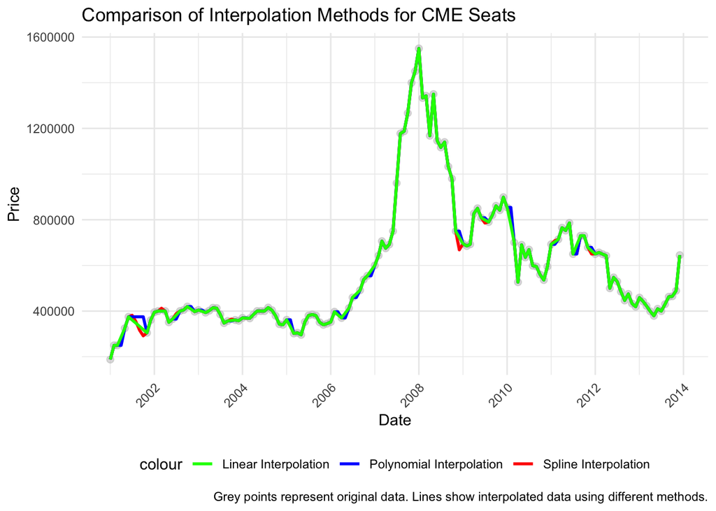

```r
library(tidyverse)
library(zoo)

# Function to load, preprocess, interpolate, and plot data
process_and_plot_data <- function(file_path, title_suffix) {
  # Load and preprocess data
  data <- read.csv(file_path)
  data$DateOfSale <- as.Date(data$DateOfSale, format = "%m/%d/%Y")
  data$Year <- year(data$DateOfSale)
  data$Month <- month(data$DateOfSale)

  # Aggregate data by month
  monthly_data <- data %>%
    group_by(Year, Month) %>%
    summarize(price = mean(price), .groups = 'drop')

  # Generate complete time series data frame
  complete_range <- expand.grid(Year = 2001:2013, Month = 1:12)
  complete_range$Date <- as.Date(with(complete_range, paste(Year, Month, "1", sep="-")))

  # Merge and interpolate
  full_data <- merge(complete_range, monthly_data, by = c("Year", "Month"), all = TRUE)
  full_data$spline_price <- na.spline(full_data$price)
  full_data$poly_price <- na.approx(full_data$price, method = "constant", f = 0, ties = mean)
  full_data$linear_price <- na.approx(full_data$price)

  # Plotting function for comparing methods
  ggplot(full_data, aes(x = Date)) +
    geom_point(aes(y = price), color = "grey", size = 2, alpha = 0.5) +  # Original data in grey
    geom_line(aes(y = spline_price, color = "Spline Interpolation"), size = 1) +
    geom_line(aes(y = poly_price, color = "Polynomial Interpolation"), size = 1) +
    geom_line(aes(y = linear_price, color = "Linear Interpolation"), size = 1) +
    scale_color_manual(values = c("Spline Interpolation" = "red", "Polynomial Interpolation" = "blue", "Linear Interpolation" = "green")) +
    labs(title = paste("Comparison of Interpolation Methods for", title_suffix, "Seats"),
         x = "Date", y = "Price",
         caption = "Grey points represent original data. Lines show interpolated data using different methods.") +
    theme_minimal() +
    scale_x_date(date_breaks = "2 years", date_labels = "%Y") +
    theme(axis.text.x = element_text(angle = 45, hjust = 1), legend.position = "bottom")
}

# Process and plot data for CME, IMM, and IOM
process_and_plot_data("/Users/devanshiledwani/Downloads/cmeS.csv", "CME")
```

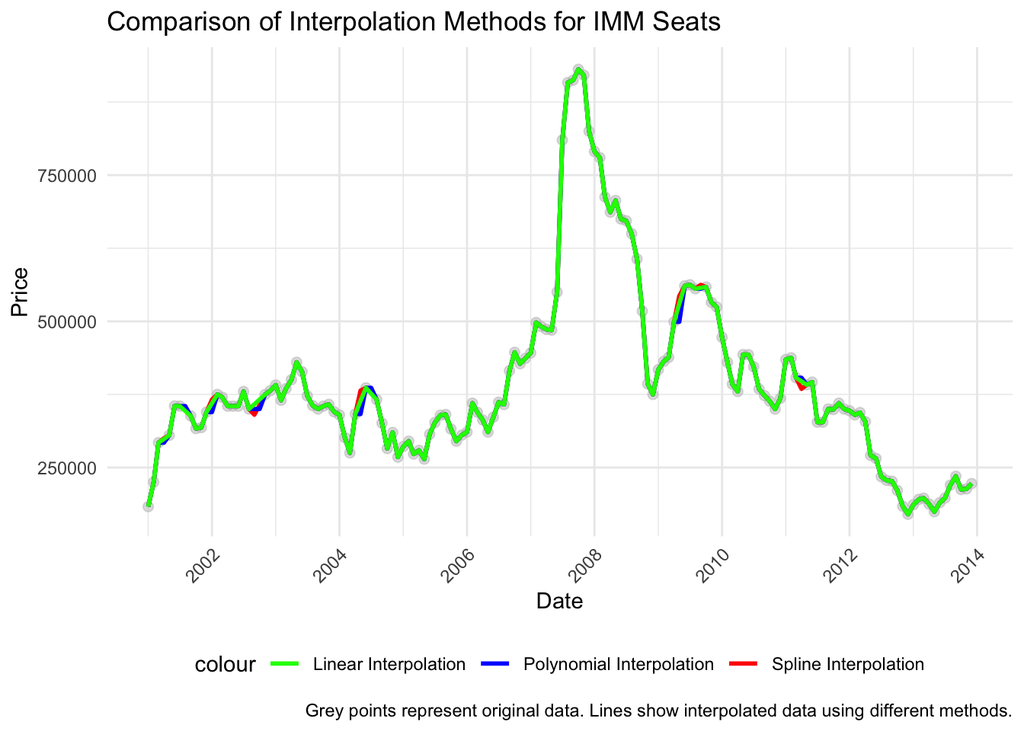

```r
process_and_plot_data("/Users/devanshiledwani/Downloads/immS.csv", "IMM")
```

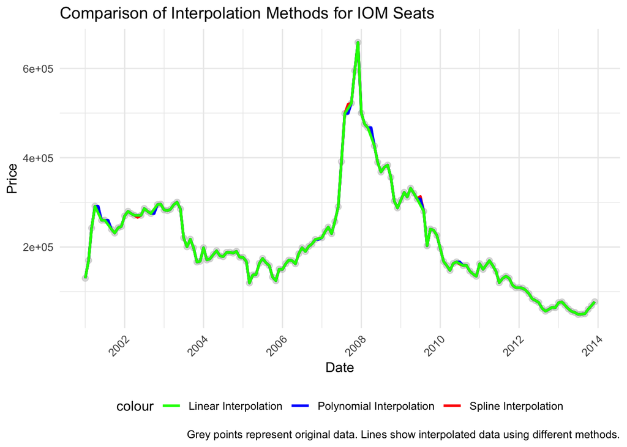

```r
process_and_plot_data("/Users/devanshiledwani/Downloads/iomS.csv", "IOM")
```

#We will try to compare interpolation for first five years for more understanding Smoothness: The smooth curve produced by spline interpolation looks to follow the data’s general trend rather than conforming too closely to isolated variations. By doing so, one can better grasp underlying trends without becoming unduly affected by small price fluctuations or anomalies. Response: The spline curve is sufficiently sensitive to catch notable changes in the data, such as the peak around 2004. However, it does not have the abruptness or oversimplicity of linear interpolation that might occasionally result from polynomial interpolation. Balance: Spline offers an excellent trade-off between preventing overfitting, which is a potential hazard with high-degree polynomial interpolation, and preserving a close match to the data.

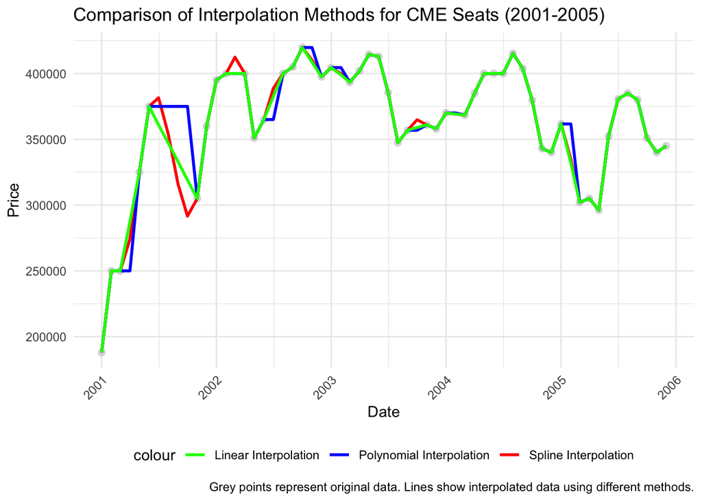

```r
library(tidyverse)
library(zoo)

# Function to process, interpolate, and plot data for a specific dataset and time period
process_and_plot_data <- function(file_path, title_suffix) {
  # Load data
  data <- read.csv(file_path)
  data$DateOfSale <- as.Date(data$DateOfSale, format = "%m/%d/%Y")
  data <- filter(data, DateOfSale >= as.Date("2001-01-01") & DateOfSale <= as.Date("2005-12-31"))
  data$Year <- year(data$DateOfSale)
  data$Month <- month(data$DateOfSale)

  # Aggregate data by month
  monthly_data <- data %>%
    group_by(Year, Month) %>%
    summarize(price = mean(price), .groups = 'drop')

  # Generate complete time series data frame for the period 2001-2005
  complete_range <- expand.grid(Year = 2001:2005, Month = 1:12)
  complete_range$Date <- as.Date(with(complete_range, paste(Year, Month, "1", sep="-")))

  # Merge and interpolate
  full_data <- merge(complete_range, monthly_data, by = c("Year", "Month"), all = TRUE)
  full_data$spline_price <- na.spline(full_data$price, na.rm = FALSE)
  full_data$poly_price <- na.approx(full_data$price, method = "constant", f = 0, na.rm = FALSE)
  full_data$linear_price <- na.approx(full_data$price, na.rm = FALSE)

  # Plotting function for comparing methods
  ggplot(full_data, aes(x = Date)) +
    geom_point(aes(y = price), color = "grey", size = 2, alpha = 0.5) +  # Original data in grey
    geom_line(aes(y = spline_price, color = "Spline Interpolation"), size = 1) +
    geom_line(aes(y = poly_price, color = "Polynomial Interpolation"), size = 1) +
    geom_line(aes(y = linear_price, color = "Linear Interpolation"), size = 1) +
    scale_color_manual(values = c("Spline Interpolation" = "red", "Polynomial Interpolation" = "blue", "Linear Interpolation" = "green")) +
    labs(title = paste("Comparison of Interpolation Methods for", title_suffix, "Seats (2001-2005)"),
         x = "Date", y = "Price",
         caption = "Grey points represent original data. Lines show interpolated data using different methods.") +
    theme_minimal() +
    scale_x_date(date_breaks = "1 year", date_labels = "%Y") +
    theme(axis.text.x = element_text(angle = 45, hjust = 1), legend.position = "bottom")
}

# Process and plot data for CME, IMM, and IOM for the first 5 years
process_and_plot_data("/Users/devanshiledwani/Downloads/cmeS.csv", "CME")
```

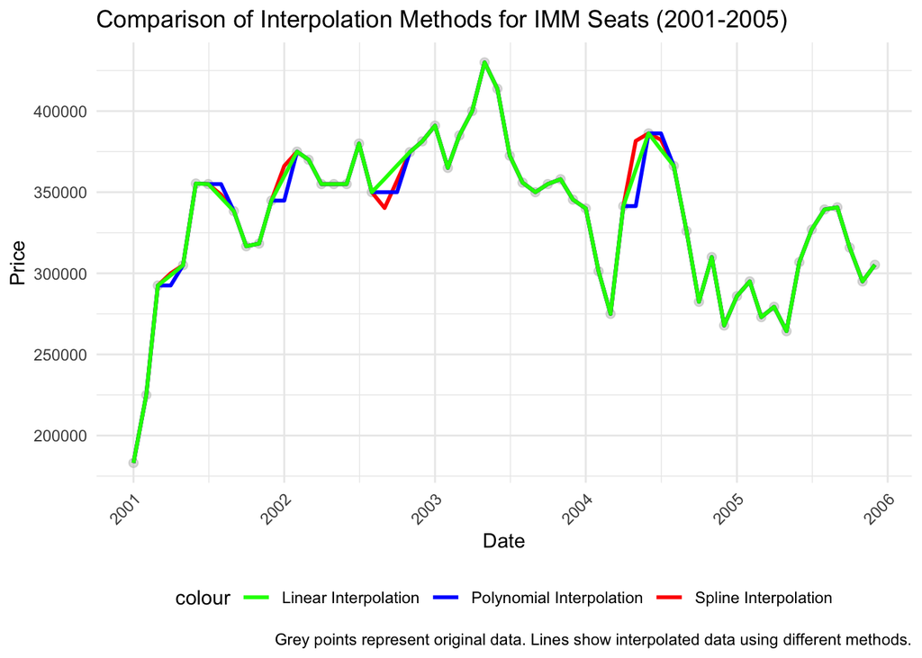

```r
process_and_plot_data("/Users/devanshiledwani/Downloads/immS.csv", "IMM")
```

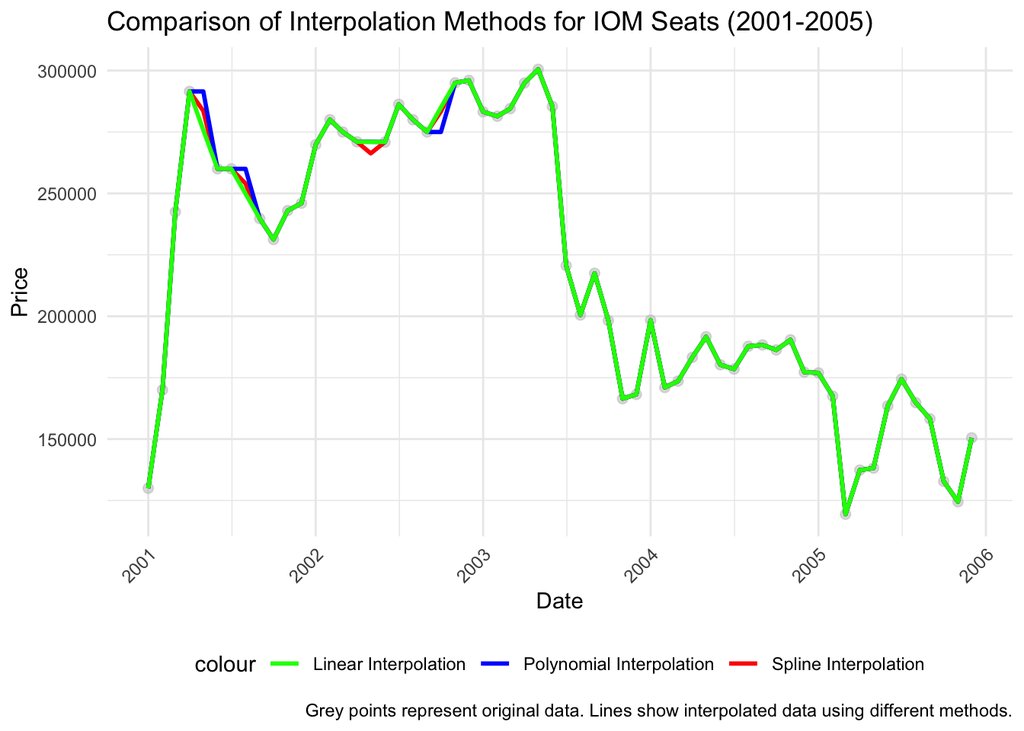

```r
process_and_plot_data("/Users/devanshiledwani/Downloads/iomS.csv", "IOM")
```

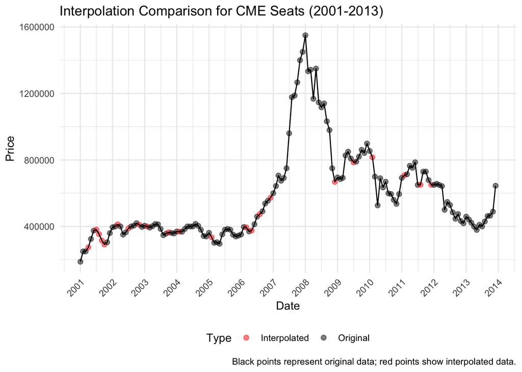

```r
library(tidyverse)
library(zoo)
library(lubridate)

# Define a function to load data, process, and plot
process_and_plot_data <- function(file_path, title_suffix) {
  # Load data
  data <- read.csv(file_path)
  data$DateOfSale <- as.Date(data$DateOfSale, format = "%m/%d/%Y")
  data <- data %>%
    mutate(Year = year(DateOfSale), Month = month(DateOfSale)) %>%
    select(-DateOfSale)

  # Aggregate data by month
  monthly_data <- data %>%
    group_by(Year, Month) %>%
    summarise(price = mean(price), .groups = 'drop')

  # Generate complete time series data frame from Jan 2001 to Dec 2013
  complete_range <- expand.grid(Year = 2001:2013, Month = 1:12)
  complete_range$Date <- as.Date(with(complete_range, paste(Year, Month, "1", sep="-")))

  # Merge and interpolate
  full_data <- merge(complete_range, monthly_data, by = c("Year", "Month"), all.x = TRUE)
  full_data$interpolated_price <- na.spline(full_data$price, na.rm = FALSE)

  # Identify original and interpolated data points
  full_data$Type <- ifelse(is.na(full_data$price), "Interpolated", "Original")

  # Plotting
  ggplot(full_data, aes(x = Date, y = interpolated_price, group = 1)) +
    geom_point(aes(color = Type), size = 2, alpha = 0.5) +
    geom_line() +
    scale_color_manual(values = c("Original" = "black", "Interpolated" = "red")) +
    labs(title = paste("Interpolation Comparison for", title_suffix, "Seats (2001-2013)"),
         x = "Date", y = "Price",
         caption = "Black points represent original data; red points show interpolated data.") +
    theme_minimal() +
    scale_x_date(date_breaks = "1 year", date_labels = "%Y") +
    theme(axis.text.x = element_text(angle = 45, hjust = 1), legend.position = "bottom")
}

# Process and plot data for CME, IMM, and IOM
process_and_plot_data("/Users/devanshiledwani/Downloads/cmeS.csv", "CME")
```

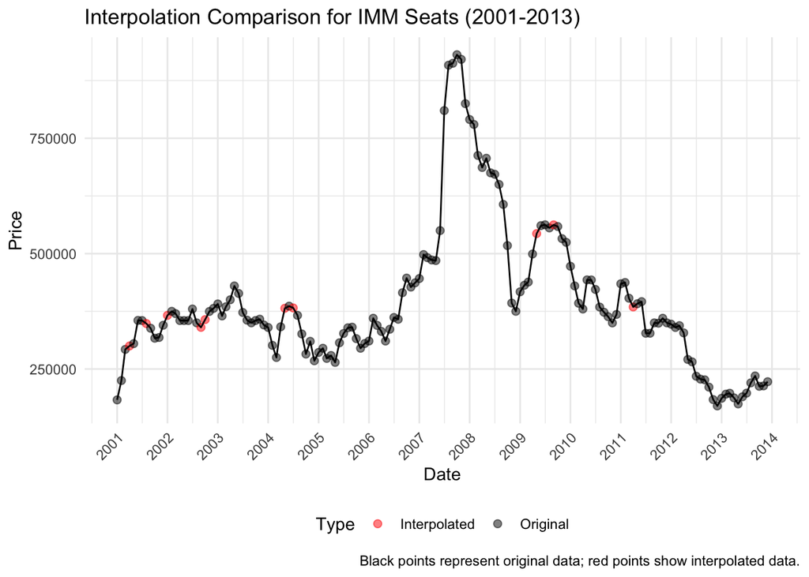

```r
process_and_plot_data("/Users/devanshiledwani/Downloads/immS.csv", "IMM")
```

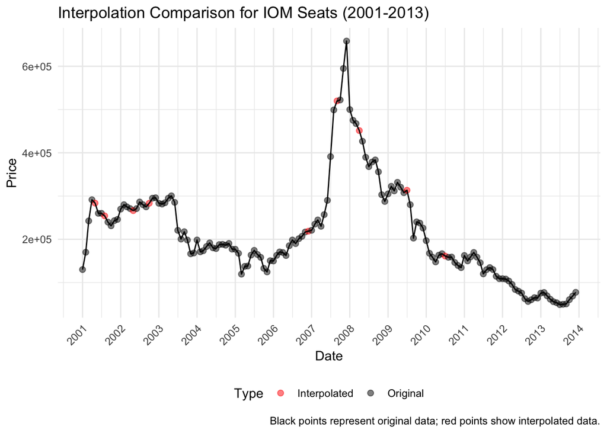

```r
process_and_plot_data("/Users/devanshiledwani/Downloads/iomS.csv", "IOM")
```